# Application of ComBat-seq on simulated dataset

library composition - biological & batch effects

Yuqing Zhang

September 25, 2018

## Design of the study

We simulated a **(2000 gene $\times$ 20 sample)** count matrix from negative binomial distributions. The dataset contains **2** batches, with **10** samples in each batch, and **biological effect - a 2-fold change between 2 condition groups**. This is still an idealistic example: 1) batch affects all genes (in the same gene group) in the same way, 2) genes have common mean and dispersion.

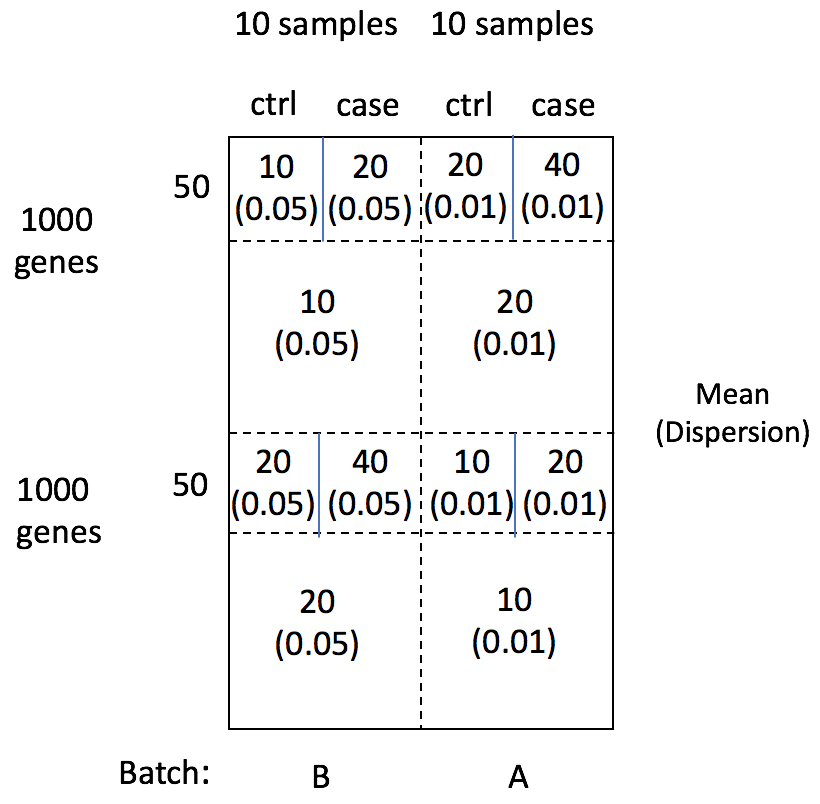

## Simulate dataset

### Distribution of counts in samples

Library sizes (average counts in each sample) are roughly similar across batches. The biologically activated samples have larger library sizes than the control samples. The dispersion parameters are different in two batches (Batch B: 0.05, Batch A: 0.01).

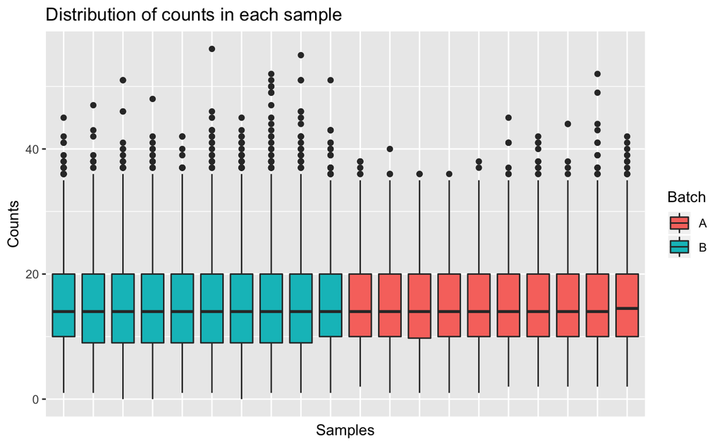

### Batch effect in the dataset

Genes are systematically different between the two batches. The first 1000 genes are higher in Batch A, while the next 1000 genes are have larger counts in Batch B. The image in the first tab below shows the average counts from each gene group.

In the second tab, we show hiearachical clustering of samples in the dataset based on the unadjusted counts. Samples are clearly clustered by batch - they cluster first by batch (text label), then by biological condition (color).

#### Counts in genes

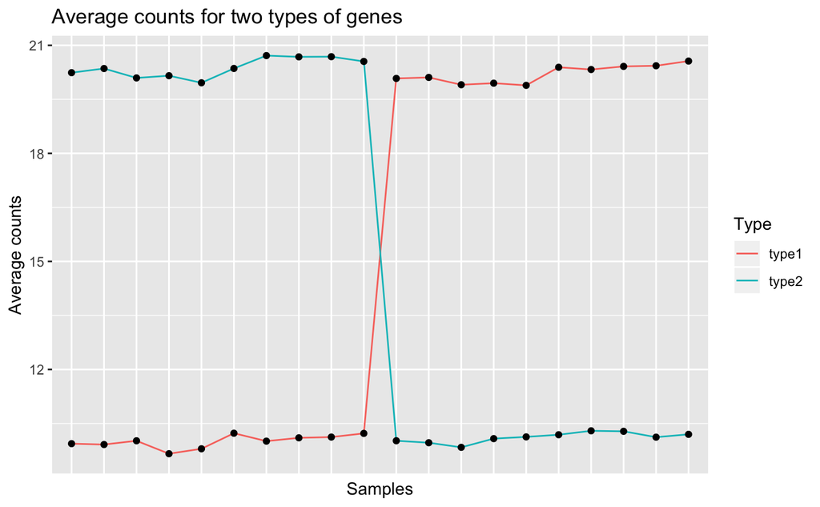

#### Clustering of samples before adjustment

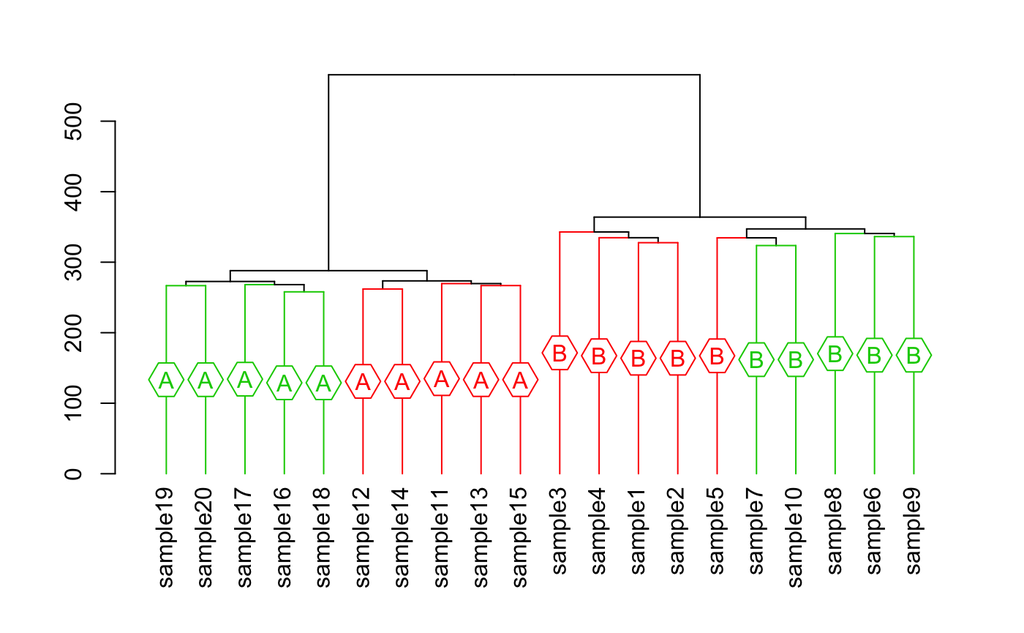

## Apply ComBat-seq

### Adjustment output

We apply ComBat-seq to the above simulated dataset. Some intermediate results of ComBat-seq are printed out to help us better understand how this function works. Running time of ComBat-seq is also recorded.

```r
start_time <- Sys.time()
adj_counts <- ComBat_seq(counts=counts, batch=batch, group=group)
```

```
Found 2 batches
Using full model in ComBat-seq.
Adjusting for 1 covariate(s) or covariate level(s)

########  Design matrix  ########
Partial design matrix:
  batchA batchB group1
1      0      1      0
2      0      1      0
3      0      1      0
4      0      1      0
5      0      1      0
6      0      1      1


########  Dispersion  ########
Estimated common dispersion:
[1] 0.01 0.05

Average estimated gene-wise dispersion:
batchA batchB
 0.023  0.057


########  GLM model coefs  ########
Coefficients (model 1):
         batchA    batchB    group1
gene1 -7.348362 -7.988528 0.3683228
gene2 -7.248985 -7.822739 0.2728507
gene3 -7.237099 -7.938539 0.3169950
gene4 -7.378839 -8.215467 0.5656910
gene5 -7.250787 -7.998836 0.3789318
gene6 -7.299945 -7.766467 0.2926121
...
            batchA    batchB       group1
gene1995 -8.147572 -7.250158 -0.064018541
gene1996 -7.935751 -7.251811  0.045405821
gene1997 -8.163331 -7.256054 -0.006887058
gene1998 -8.050135 -7.367222  0.042749655
gene1999 -7.952411 -7.377403 -0.031214330
```

[output cut: 37 more lines]

```

Prior average dispersion:
    batchA     batchB
0.02265265 0.05719544

Posterior average dispersion:
    batchA     batchB
0.01726850 0.05235997

Batch-free mean mu:
[1] 14.25591
[1] 14.34917

Batch-free dispersion phi:
[1] 0.03481423
```

```r
end_time <- Sys.time()
cat("\nRunning time of ComBat-seq:\n")
```

```
Running time of ComBat-seq:
```

```r
print(end_time - start_time)
```

```
Time difference of 32.48356 secs
```

### Visualize adjusted data

Similar as above, we visualize the adjusted counts in each sample (first tab), and the average adjusted counts from each gene group (second tab). Also, in the third tab, we can see that after the ComBat-seq adjustment, samples are no longer clustered by batch - rather, they cluster by biological condition as desired.

#### Distribution of adjusted counts in samples

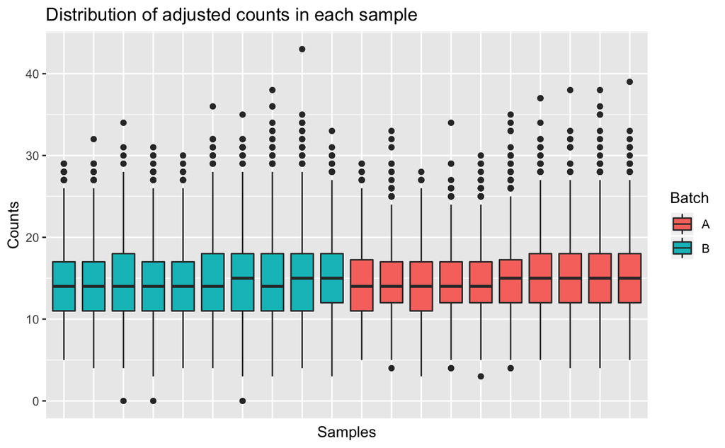

#### Adjusted counts in genes

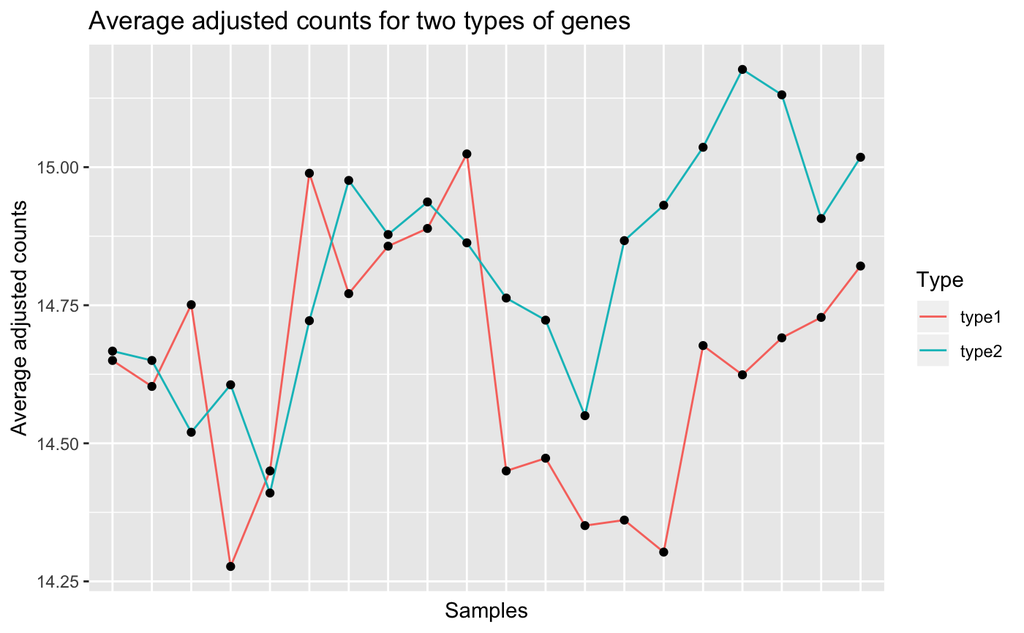

#### Clustering of samples after adjustment

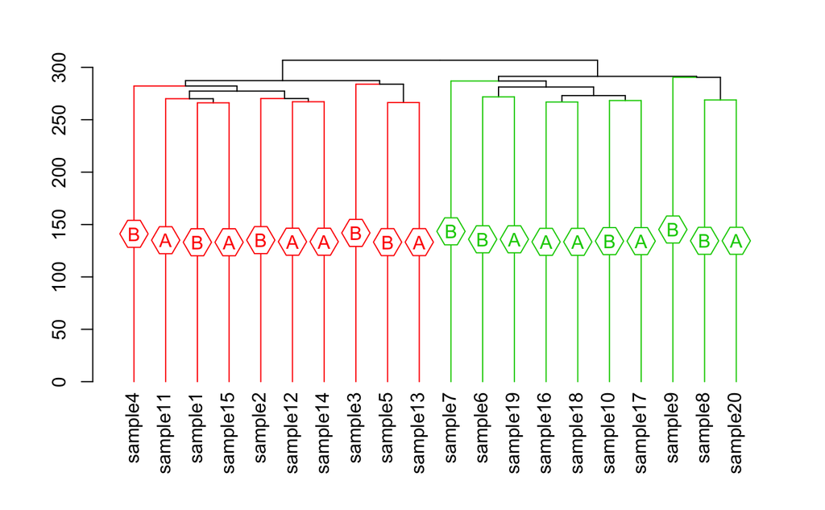

## Differential Expression

### edgeR

```
Performance using un-adjusted P values
```

|  | Unadj | OneStep | CombatSeq |
| --- | --- | --- | --- |
| tpr | 0.45 | 0.86 | 0.89 |
| fpr | 0.00 | 0.05 | 0.06 |

```
Performance using FDR corrected p values
```

|  | Unadj | OneStep | CombatSeq |
| --- | --- | --- | --- |
| tpr | 0 | 0.43 | 0.40 |
| fdr | NaN | 0.09 | 0.09 |

### DESeq2

```
Performance using un-adjusted P values
```

|  | Unadj | OneStep | CombatSeq |
| --- | --- | --- | --- |
| tpr | 0.50 | 0.79 | 0.85 |
| fpr | 0.01 | 0.04 | 0.05 |

```
Performance using FDR corrected p values
```

|  | Unadj | OneStep | CombatSeq |
| --- | --- | --- | --- |
| tpr | 0.01 | 0.72 | 0.67 |
| fdr | 1.00 | 0.96 | 0.96 |

## Thoughts

- We do have a computational problem when the total number of genes reach 20000 (i.e., if we simulate the count matrix to contain 20000 rows instead of 2000, the function will take >20mins to run). Need to optimize the algorithm.